# Random forests for linguistic analysis

Jason Grafmiller

08 January, 2021

In this tutorial, we’ll go over the basics of how to use **random forests**, which are an extension of the decision tree methods we explored earlier.

**Advantages of random forests:**

- **Small n, big p**: Random forests can handle small datasets with relatively large sets of predictors. This is a problem for other methods
- Random forests are also robust against problems of collinearity due to their bagging and random variable selection procedures.
- Random forests deal well with nonlinear effects and high-order interactions (though care should be taken, see Wright et al. 2016)
- **Very accurate**: Random forests are typically much more accurate than single trees and even regression models

**Disadvantages of random forests:**

- Cannot handle non-independence well. They don’t have a way of incorporating hierarchical data structures, i.e.“random” effects for speaker, text, etc.
- Potentially long computing time (especially for variable imortance)
- Do not provide traditional measures of effect size, direction, or significance

# Setup

Before we get started, let’s load our basic libraries.

```r
# install and load
library(tidyverse)
library(tictoc) # for timing
library(patchwork)

# for random forests
library(randomForest)
library(ranger)
library(party)
library(permimp)
library(edarf)
```

# Datasets

For for classification trees we’ll use some of the datasets we looked at before.

```r
# These two are big files so I have saved them as more efficient .rds files. These are not readable with other programs, e.g. Excel, but they take up less space and are quicker to load.
gens <- readRDS("data_raw/brown_genitives.rds")
rels <- readRDS("data_raw/brown_relatives.rds")
# read from usual .csv file
english <- readRDS("data_raw/english_lexical_decision_Baayen.rds")
```

# What are Random Forests?

Random forests are a powerful technique for predictive modeling and statistical inference. In a random forest we grow many trees trees as opposed to a single tree. To create the model, each tree makes a prediction and we say the tree “votes” for that outcome. For classification problems, the forest chooses the class having the most votes over all the trees in the forest. In case of regression, the forest takes the average of the predictions over all the different trees.

To understand why we might want to use random forests, it’s helpful to see the kinds of problems the method helps solve. One well-known problem with using single tree models is that the tree structure is highly sensitive to particulars of your dataset, because each split (after the initial one) depends on previous ones. Random Forests offer a solution to this problem.

We can illustrate this with a few random samples from the genitives dataset. We’ll start with the formula for genitive choice from previous tutorial. We’ll start with this.

```r
gen_fmla2 <- Type ~ Possessor.Animacy.Bin + Final.Sibilant +
  Possessor.Word.Count + Semantic.Relation.Bin + Possessor.Expression.Type +
  Genre + Corpus + Possessum.Word.Count + PossessorTextFreq +
  PossessumTextFreq + Prior.Genitive
```

Reset our factors.

```r
factors <- c("Possessor.Animacy.Bin", "Final.Sibilant", "Semantic.Relation.Bin",
  "Possessor.Expression.Type", "Genre", "Corpus", "Prior.Genitive")
gens[factors] <- lapply(gens[factors], as.factor)
```

```r
set.seed(43214) # set the random seed
library(partykit) # note that this will mask functions from party
```

Now will take several random subsamples of our dataset and fit trees to them.

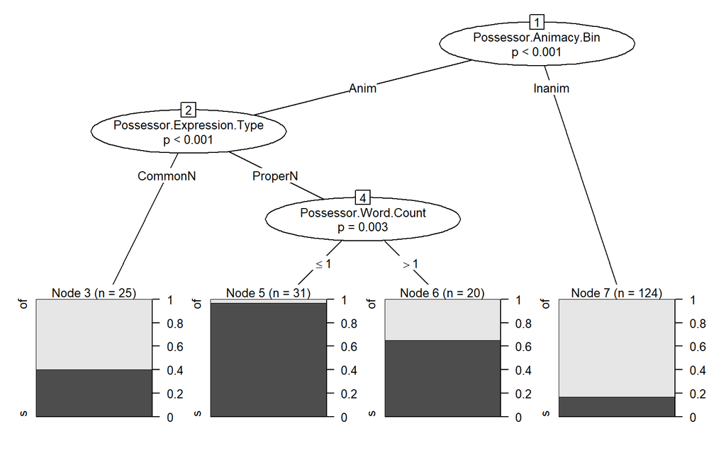

```r
ctree(gen_fmla2,
  data = gens[sample(1:nrow(gens), 200, replace = F),],
  control = ctree_control(mincriterion = .99, maxdepth = 4)) %>%
  plot(gp = gpar(cex = .8))
```

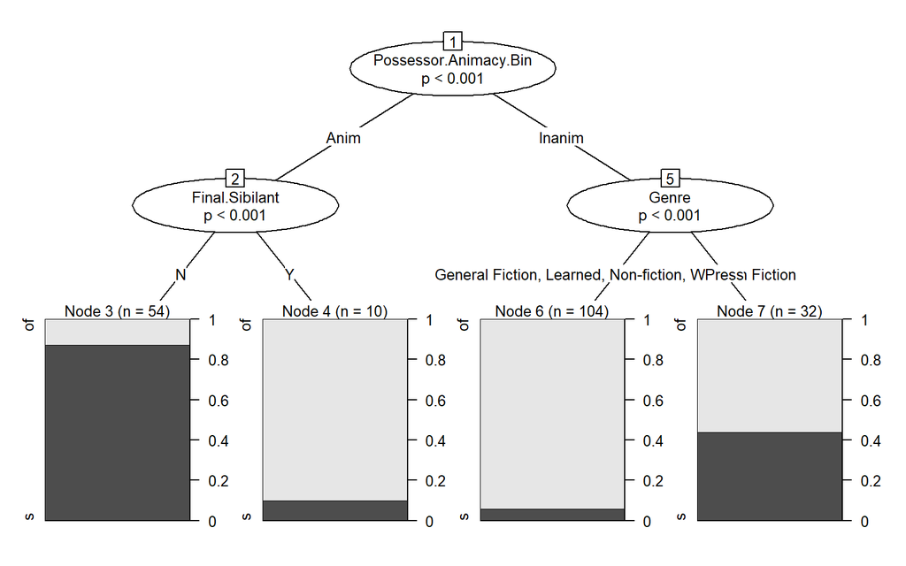

```r
ctree(gen_fmla2,
  data = gens[sample(1:nrow(gens), 200, replace = F),],
  control = ctree_control(mincriterion = .99, maxdepth = 4)) %>%
  plot(gp = gpar(cex = .8))
```

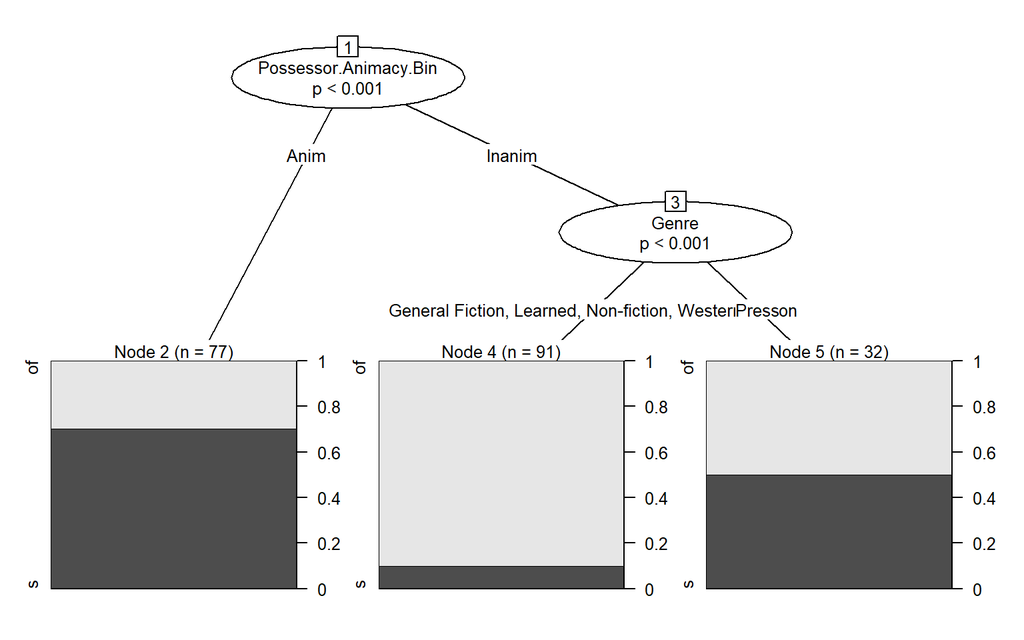

```r
ctree(gen_fmla2,
  data = gens[sample(1:nrow(gens), 200, replace = F),],
  control = ctree_control(mincriterion = .99, maxdepth = 4)) %>%
  plot(gp = gpar(cex = .8))
```

Now, these are samll datasets (N = 200), and with larger samples we would likely get more convergence among the trees (try it your self!). But the larger point is that tree structures are highly volatile and sensitive to the particulars of the datasets they are trained on.

Random forests are one way of getting around this problem. They are one of a family of techniques that use **ensemble methods** to generate predictions. These methods rely on aggregating and summarising over lots of models rather than relying on one single model to derive predictions.

## Bagging

One aspect of the random forests involves a process known as [**Bootstrap Aggregating**](https://en.wikipedia.org/wiki/Bootstrap_aggregating), or **bagging**. Bagging is a technique used to reduce the variance of our predictions from individual trees by combining the result of many hundreds or thousands of trees trained on different sub-samples of the dataset. In this way, bagging is designed to improve the reliability and accuracy of a model as well as reduce variance and potential overfitting.

To obtain subsamples of the data, bagging relies on the principle of random sampling with replacement, or **bootstrapping**. The basic idea of bootstrapping goes as follows. Given a data set $D_1$ with $n$ observations, we create a new dataset $D_2$ by randomly pulling out $n$ observations from the original dataset $D_1$, allowing that some of those observations may be copies. This is known as sampling “with replacement”, which simply means that each time we take a sample item from our set, we “replace” it with a copy in the original dataset. So the pool from which we draw our samples always stays the same, meaning that we could draw that same item again.

For example, suppose our dataset contained 26 observations, which we code with letters.

```r
D1 <- letters
D1
```

```
 [1] "a" "b" "c" "d" "e" "f" "g" "h" "i" "j" "k" "l" "m" "n" "o" "p" "q" "r" "s"
[20] "t" "u" "v" "w" "x" "y" "z"
```

Now we take a sample of these observations by selecting a letter at random 26 times. This is our **bootstrap sample**.

```r
D2 <- sample(D1, replace = T)
D2
```

```
 [1] "z" "s" "e" "j" "w" "t" "a" "j" "d" "v" "f" "v" "p" "s" "r" "g" "d" "u" "a"
[20] "e" "q" "d" "i" "l" "b" "g"
```

We can already see that some observations are repeated. This is the effect of sampling with replacement. We can see the proportion of non-repeated items…

```r
# your mileage may vary
length(unique(D2))/length(D2)
```

```
[1] 0.6923077
```

Usually, about 1/3 of the observations from D1 are left out of D2. This is typical no matter how large the original dataset is.

One thing it’s important to remember is that because we’re moving into methods that rely on (pseudo) randomness, our results may vary across runs. This is why it’s important to set the **random seed** prior to running our models so that we can replicate our results again. All computer programs use pseudonrandom number algoritms to simulate randomness, and R is no different. We can take advantage of this to make sure we get the same results. We do this by setting the initial state of the random number generator to a predefined value with `set.seed()`. This can be any value.

```r
set.seed(43214)
```

Which value you choose doesn’t matter in itself, but starting at that seed will always produce the same results.

Make sure to set this, and track it in your code so that you and anyone else can reproduce your analysis.

## Random predictor sampling

A second aspect of random forests that makes them different from standard bagging methods is that when growing the individual trees, the method adds a second element of randomness in the selection of predictors that are included in each tree. When we have *k* input predictors, the random forest will randomly select a subset *m* < *k* out of the *k* predictors at each node, in each tree. The best split on these *m* predictors is used to split the node.

To sum up, instead of using a single tree, Random Forests grow many many decsion trees (a ‘forest’), each of which is grown on random subsamples of the data using randomly selected subsets of predictors. This results in a healthy mix of very diverse trees, which compensates for sparse values in the data while at the same time giving full consideration to possible effects of all predictors.

# Random forests in R

## Setting controls

In addition to the tunings for the individual trees, we need to specify two important (hyper)parameters for all random forest methods:

- The number of input predictors randomly selected at each node of a given tree in the forest. We’ll call this $m$
- The total number of trees to grow in the forest. We’ll call this $N_{tree}$

As a rule of thumb, Breiman (2001) recommends setting $m$ equal to $\sqrt{k}$ for a model with $k$ predictors. The number of trees is something that is a bit harder to determine. Generally speaking, the smaller your dataset, and/or the larger the number of predictors, the more trees you should grow.

There are many more such hyperparameters we can set, and there are methods for exploring just what the optimal hyperparameter settings might be, but these can be very time consuming (prohibitively so with `{party}` forests), and are generally better suited to applications in which prediction is the primary goal. We will not go into this here, but see [**this post on tuning random forest hyperparameters**](https://www.r-bloggers.com/2020/03/tuning-random-forest-hyperparameters-with-tidytuesday-trees-data/) for an illustration.

## `randomForest` package

We’ll set the number of trees to grow at 2000, and set *m* to 3 ($\sqrt{11}$ = 3.3166248)

```r
length(all.vars(gen_fmla2))
```

```
[1] 12
```

We’ll also include the argument `importance = TRUE`, whoch will tell the model to provide a relative measure of how much each individual predictor adds to the predictive accuracy of the model. This will add to the computation time.

```r
set.seed(1234)
# time the process
tic("Time to fit randomForest")
gen_for_randomForest <- randomForest(
  gen_fmla2,
  data = gens,
  ntree = 2000,
  mtry = 3,
  importance = TRUE)
toc()
```

```
Time to fit randomForest: 24.89 sec elapsed
```

So this didn’t take too long. Let’s look at the summary.

```r
print(gen_for_randomForest)
```

```
Call:
 randomForest(formula = gen_fmla2, data = gens, ntree = 2000,      mtry = 3, importance = TRUE)
               Type of random forest: classification
                     Number of trees: 2000
No. of variables tried at each split: 3

        OOB estimate of  error rate: 12.43%
Confusion matrix:
     of    s class.error
of 2923  279  0.08713304
s   369 1644  0.18330849
```

The printout gives us an estimate of accuracy based on the **out-of-bag** (OOB) error rates. “out-of-bag” refers to those observations that are left out of the randomly sampled “bag” of data used to train the trees For each tree, we test its predictions on these OOB observations and derive an error rate. The average error over all the trees is the estimated prediction error for the forest as a whole. In other words, the predictive accuracy is 1 - the OOB error rate, or 0.88.

We can obtain predictions with the `predict()` function, and we can measure the accuracy based on this.

```r
gen_for_randomForest_preds <- predict(gen_for_randomForest)

which(gen_for_randomForest_preds == gens$Type) %>%
  length(.)/nrow(gens)
```

```
[1] 0.875743
```

We can also get the predicted probabilities themselves, and measure the index of concordance *C* using `somers2()` in the `{Hmisc}` package.

```r
gen_for_probs <- predict(gen_for_randomForest, type = "prob") %>%
  as.data.frame
head(gen_for_probs)
```

|  | of | s |
| --- | --- | --- |
| 1 | 0.74581006 | 0.25418994 |
| 2 | 0.01216216 | 0.98783784 |
| 3 | 0.08906883 | 0.91093117 |
| 4 | 0.01355014 | 0.98644986 |
| 5 | 0.64294479 | 0.35705521 |
| 6 | 0.97593583 | 0.02406417 |

```r
Hmisc::somers2(gen_for_probs$s,
  as.numeric(gens$Type) - 1)
```

```
           C          Dxy            n      Missing
   0.9289602    0.8579204 5215.0000000    0.0000000
```

Very nice! Scores above .8 indicate good discrimination.

Random forests also work for categorical response of more than 2 levels, as well as continuous responses.

```r
# Our relatives dataset
f <- rel ~ variety + time2 + RCLn + antLN + antPOS + antNum + precRel + antFreq + nested
set.seed(1234)
tic()
rel_randomForest <- randomForest(f,
  data = rels,
  ntree = 1000,
  mtry = 3,
  importance = TRUE)
toc()
```

```
45.96 sec elapsed
```

```r
print(rel_randomForest)
```

```
Call:
 randomForest(formula = f, data = rels, ntree = 1000, mtry = 3,      importance = TRUE)
               Type of random forest: classification
                     Number of trees: 1000
No. of variables tried at each split: 3

        OOB estimate of  error rate: 37.6%
Confusion matrix:
      THAT WHICH ZERO class.error
THAT  4647  1445  687   0.3145007
WHICH 1496  3640  267   0.3263002
ZERO  1345   617 1432   0.5780790
```

Not a bad model, but it could be better…

Now a model predicting a continuous response.

```r
# predict lexical decision times
lexdec_fmla <- RTlexdec ~ AgeSubject + WordCategory + WrittenFrequency + InflectionalEntropy + DerivationalEntropy + NumberSimplexSynsets + LengthInLetters + Ncount + CV

cats <- c("AgeSubject", "WordCategory", "CV")
english[cats] <- lapply(english[cats], as.factor)

set.seed(1234)
tic()
lexdec_randomForest <- randomForest(
  lexdec_fmla,
  data = english,
  ntree = 1000,
  mtry = 3,
  importance = FALSE)
toc()
```

```
58.88 sec elapsed
```

```r
print(lexdec_randomForest)
```

```
Call:
 randomForest(formula = lexdec_fmla, data = english, ntree = 1000,      mtry = 3, importance = FALSE)
               Type of random forest: regression
                     Number of trees: 1000
No. of variables tried at each split: 3

          Mean of squared residuals: 0.006732273
                    % Var explained: 72.65
```

So because this is a continuous response, what we get is measure of variance explained, i.e. the $R^2$ measure, rather than the error rate. In general, I don’t recommend using trees and forests to model continuous outcomes, but it can be done.

## `ranger` package

```r
tic("Time to fit 3 ranger forests")

tic("Gini impurity importance")
gen_ranger_gini <- ranger(gen_fmla2, data = gens,
    seed = 1234,
    num.trees = 2000,
    mtry = 3,
    importance = "impurity")
toc(log = T)
```

```
Gini impurity importance: 2.69 sec elapsed
```

```r
tic("Corrected Gini impurity importance")
gen_ranger_gini_cor <- ranger(
  gen_fmla2,
  data = gens,
  seed = 1234,
  num.trees = 2000,
  mtry = 3,
  importance = "impurity_corrected")
toc(log = T)
```

```
Corrected Gini impurity importance: 3.54 sec elapsed
```

```r
tic("Permutation importance")
gen_ranger_perm <- ranger(
  gen_fmla2,
  data = gens,
  seed = 1234,
  num.trees = 2000,
  mtry = 3,
  importance = "permutation")
toc(log = T)
```

```
Permutation importance: 5.25 sec elapsed
```

```r
toc()
```

```
Time to fit 3 ranger forests: 11.48 sec elapsed
```

One advantage of `{ranger}` is that it is fast! We fit three models in half the time it took to fit just one in `{randomForest}`.

We can check the OOB error.

```r
print(gen_ranger_gini)
```

```
Ranger result

Call:
 ranger(gen_fmla2, data = gens, seed = 1234, num.trees = 2000,      mtry = 3, importance = "impurity")

Type:                             Classification
Number of trees:                  2000
Sample size:                      5215
Number of independent variables:  11
Mtry:                             3
Target node size:                 1
Variable importance mode:         impurity
Splitrule:                        gini
OOB prediction error:             12.64 %
```

The OOB error rate is very similar to the previous model. One nice thing about `{ranger}` is that the predictions come as part of the model object.

```r
# Get the predicted class for the first 25 observations
gen_ranger_gini$predictions %>%
  head(25)
```

```
 [1] of s  s  s  of of of s  s  s  of s  of s  s  s  s  of s  s  s  of of s  s
Levels: of s
```

Another advantage of `{ranger}` is that you can fit **probability forests**, where the predicted outcome is not a discrete class, but the estimated probability of each class for each observation. You do this by specifying `probability = TRUE`.

```r
gen_ranger_prob <- ranger(
  gen_fmla2,
  data = gens,
  seed = 1234,
  num.trees = 2000,
  mtry = 3,
  probability = TRUE,
  importance = "permutation")
```

Now the predictions is a table of probabilities.

```r
gen_ranger_prob$predictions %>%
  head(10)
```

```
              of         s
 [1,] 0.74170843 0.2582916
 [2,] 0.04039655 0.9596035
 [3,] 0.12693198 0.8730680
 [4,] 0.07311901 0.9268810
 [5,] 0.62379038 0.3762096
 [6,] 0.88142290 0.1185771
 [7,] 0.52045413 0.4795459
 [8,] 0.04934973 0.9506503
 [9,] 0.02549094 0.9745091
[10,] 0.13825703 0.8617430
```

We can get the concordance index as so.

```r
Hmisc::somers2(gen_ranger_prob$predictions[,2],
  as.numeric(gens$Type) - 1)
```

```
           C          Dxy            n      Missing
   0.9375944    0.8751888 5215.0000000    0.0000000
```

We can also get continuous forests with `{ranger}` as well.

```r
tic()
lexdec_ranger <- ranger(
  lexdec_fmla,
  data = english,
  num.trees = 2000,
  mtry = 3,
  importance = "permutation"
  )
toc()
```

```
8.16 sec elapsed
```

Again, it runs in a fraction of the time as before, with the same accuracy.

```r
print(lexdec_ranger)
```

```
Ranger result

Call:
 ranger(lexdec_fmla, data = english, num.trees = 2000, mtry = 3,      importance = "permutation")

Type:                             Regression
Number of trees:                  2000
Sample size:                      4568
Number of independent variables:  9
Mtry:                             3
Target node size:                 5
Variable importance mode:         permutation
Splitrule:                        variance
OOB prediction error (MSE):       0.006716755
R squared (OOB):                  0.7272218
```

## `party` package

Now we’ll try `cforest()` in the `{party}` package, since random forests have not been fully implemented in `{partykit}`. We detach `{partykit}` and load `{party}`. This is important to avoid conflicts between the two packages which share many of the same functions. This package relise on conditional inference methods similar to those in `{partykit}`.

```r
detach("package:partykit", unload = TRUE)
library(party)
```

For `{party}`, we need to set the controls in the `cforest_control()` function. Once we’ve set our control parameters, we can fit our tree with `cforest()`. We will start with a simpler model, because this method is *much* slower than the others.

```r
ctrl <- cforest_control(mtry = 3, ntree = 2000) # same settings as above

gen_fmla_simple <- Type ~ Possessor.Animacy.Bin + Final.Sibilant + Possessor.Word.Count + Genre + Corpus

set.seed(1234)
tic("Time to fit party forest")
gen_party1 <- cforest(
  gen_fmla_simple,
  data = gens,
  controls = ctrl)
toc()
```

```
Time to fit party forest: 63.96 sec elapsed
```

So`cforest()` is not as fast as `{ranger}`, but it has its advantages… And the output of the `cforest()` function is sadly not very informative.

```r
print(gen_party1)
```

```
     Random Forest using Conditional Inference Trees

Number of trees:  2000

Response:  Type
Inputs:  Possessor.Animacy.Bin, Final.Sibilant, Possessor.Word.Count, Genre, Corpus
Number of observations:  5215
```

Note also that random forests, especially cforests are *very* large objects (at least > 100Mb) so they can be slow to load and can bog down your system.

We can get the predictions from the model with `treeresponse()`, which computes the estimated conditional class probabilities for the forest. This is similar to what you get with a probablity tree in `{rnager}`. Note that this may take some time.

```r
tic("Time to get predictions from party forest")
gen_party1_preds <- treeresponse(gen_party1)
toc()
```

It took 20 minutes on my machine (I wasn’t kidding, `{party}` is sloooow), so I recommend only running these when you have time.

We can see what these look like.

```r
head(gen_party1_preds)
```

```
$`1`
       Type.of    Type.s
[1,] 0.4033834 0.5966166

$`2`
        Type.of   Type.s
[1,] 0.06482296 0.935177

$`3`
        Type.of   Type.s
[1,] 0.06482296 0.935177

$`4`
        Type.of   Type.s
[1,] 0.06482296 0.935177

$`5`
       Type.of    Type.s
[1,] 0.4033834 0.5966166

$`6`
       Type.of    Type.s
[1,] 0.7645003 0.2354997
```

The output of `treeresponse()` is a list, so we can convert this to a dataframe for easier reading.

```r
gen_party1_preds_df <- do.call("rbind", gen_party1_preds) %>%
  as.data.frame()

# Look at the predictions for the first 10 observations
head(gen_party1_preds_df, 10)
```

|  | Type.of | Type.s |
| --- | --- | --- |
| 1 | 0.40338336 | 0.5966166 |
| 2 | 0.06482296 | 0.9351770 |
| 3 | 0.06482296 | 0.9351770 |
| 4 | 0.06482296 | 0.9351770 |
| 5 | 0.40338336 | 0.5966166 |
| 6 | 0.76450026 | 0.2354997 |
| 7 | 0.13947424 | 0.8605258 |
| 8 | 0.06482296 | 0.9351770 |
| 9 | 0.06482296 | 0.9351770 |
| 10 | 0.13947424 | 0.8605258 |

Get the concordance index as usual.

```r
Hmisc::somers2(gen_party1_preds_df[,2], as.numeric(gens$Type) - 1)
```

```
           C          Dxy            n      Missing
   0.9069422    0.8138843 5215.0000000    0.0000000
```

# Predictor importance

Unlike single trees or regression models, reading partial effects off a random forest model is not easy because a single predictor can show up in many different (non-nested) trees with different co-varying predictors (and interactions). So random forests don’t give you direct effect size measures comparable to regression coefficients, nor to they conduct null hypothesis significance tests for your predictors, as with regression models.

But, random forests and ensemble methods make up for this shortcoming in being a great tool for model and predictor selection. Due to the random sampling and permutation processes, they are very good at determining the independent contributions of individual predictors to the model even when those predictors are highly correlated with one another (as is often the case). And since they rely on many, many trees, they can model non-linearities and complex ‘interactions’ quite naturally. All this results in us gaining much more information about how each predictor behaves.

To assess the contribution of each predictor, the random forest models compute a **predictor importance** score (also called “variable importance”). That’s what the `importance` arguments were for in the functions above.

The `randomForest` method uses decrease in predictive accuracy, and decrease in Gini index averaged over all the trees in the forest. These are measures of how much the accuracy or Gini index decreases when we that predictor is not present.

```r
gen_for_randomForest$importance
```

```
                                   of           s MeanDecreaseAccuracy
Possessor.Animacy.Bin     0.076799245 0.119862870          0.093391501
Final.Sibilant            0.009060493 0.019372709          0.013033765
Possessor.Word.Count      0.040229240 0.057000005          0.046679529
Semantic.Relation.Bin     0.003386031 0.006858924          0.004725135
Possessor.Expression.Type 0.029855126 0.059263000          0.041177214
Genre                     0.021982018 0.037877047          0.028109092
Corpus                    0.023946023 0.022243013          0.023286108
Possessum.Word.Count      0.095167124 0.064626965          0.083371722
PossessorTextFreq         0.016315750 0.017961225          0.016945819
PossessumTextFreq         0.010105335 0.003255032          0.007463762
Prior.Genitive            0.003091606 0.003999614          0.003440257
                          MeanDecreaseGini
Possessor.Animacy.Bin            469.52224
Final.Sibilant                    64.57746
Possessor.Word.Count             219.70573
Semantic.Relation.Bin             34.85137
Possessor.Expression.Type        220.99800
Genre                            170.31421
Corpus                            75.95838
Possessum.Word.Count             329.03892
PossessorTextFreq                193.81829
PossessumTextFreq                166.12233
Prior.Genitive                    55.96642
```

Let’s look at the Gini measure.

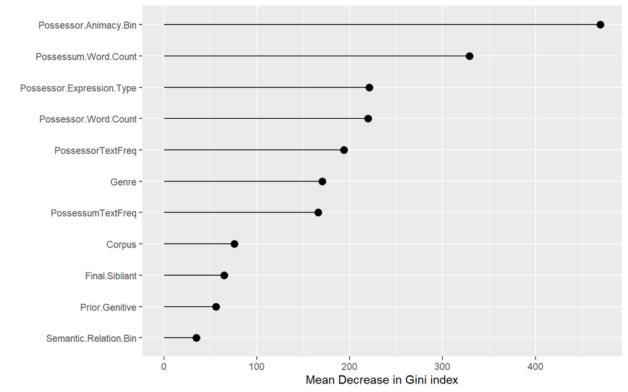

```r
gen_for_randomForest$importance %>%
  as.data.frame %>%
  rownames_to_column("Predictor") %>%
  ggplot(aes(fct_reorder(Predictor, MeanDecreaseGini), MeanDecreaseGini)) +
  geom_segment(aes(xend = Predictor, yend = 0)) +
  geom_point(size = 3) +
  labs(x = "", y = "Mean Decrease in Gini index") +
  coord_flip()
```

> To evaluate predictor importance, a tree is grown in the first step, and the prediction accuracy in the OOB observations is calculated. In the second step, any association between the variable of interest $x_i$ and the outcome is broken by permuting the values of all individuals for $x_i$, and the prediction accuracy is computed again. The difference between the two accuracy values is the permutation importance for $x_i$ from a single tree. The average of all tree importance values in a random forest then gives the random forest permutation importance of this variable. The procedure is repeated for all predictors of interest.

In other words, we…

1. Grow a tree predicting a response from a set of predictors.
2. Take one predictor and randomly shuffle the values of that predictor to break the association between the response and predictor
3. Calculate the difference in model accuracy before and after shuffling.
4. Repeat for all trees and all predictors in the forest

If the predictor does not have a meaningful relationship with the response, shuffling its values should produce very little change in model accuracy. On the other hand, if the predictor was strongly associated with the response, permutation should create a large drop in accuracy. We do this for every predictor in the model, and rank them according to their importance.

Permutation variable importance covers the individual impact of each predictor in the random forest model, including its impact in interactions (which is much harder to assess in regression models).

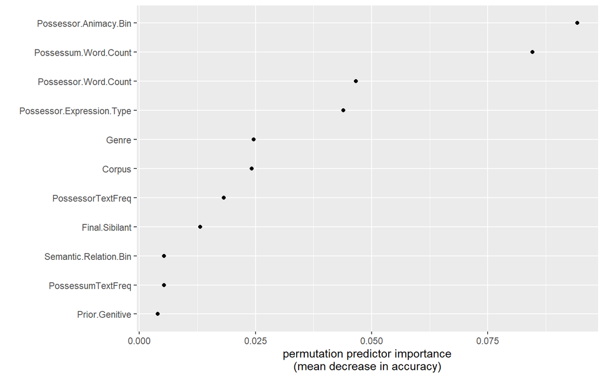

```r
gen_ranger_varimp <- importance(gen_ranger_perm) %>%
  as.data.frame %>%
  rename(varimp = ".") %>%
  mutate(pred = rownames(.) %>% factor)

ggplot(gen_ranger_varimp, aes(fct_reorder(pred, varimp), varimp)) +
  geom_point() +
  labs(x = "", y = "permutation predictor importance\n(mean decrease in accuracy)") +
  coord_flip()
```

```r
# track the time it takes to run
tic()
gen_party1_varimp <- permimp(
  gen_party1,
  AUC = TRUE, # use the AUC (concordance index) rather than accuracy
  progressBar = FALSE # don't print a progress bar here
  )
toc()
```

```
111.44 sec elapsed
```

```r
gen_party1_varimp
```

```
Possessor.Animacy.Bin        Final.Sibilant  Possessor.Word.Count
         0.1849457619          0.0176165402          0.0750757129
                Genre                Corpus
         0.0510407999          0.0004802237
```

Once we have our variable importance object, we can plot the results. First we convert it to a data.frame object which we can then use with `ggplot()`.

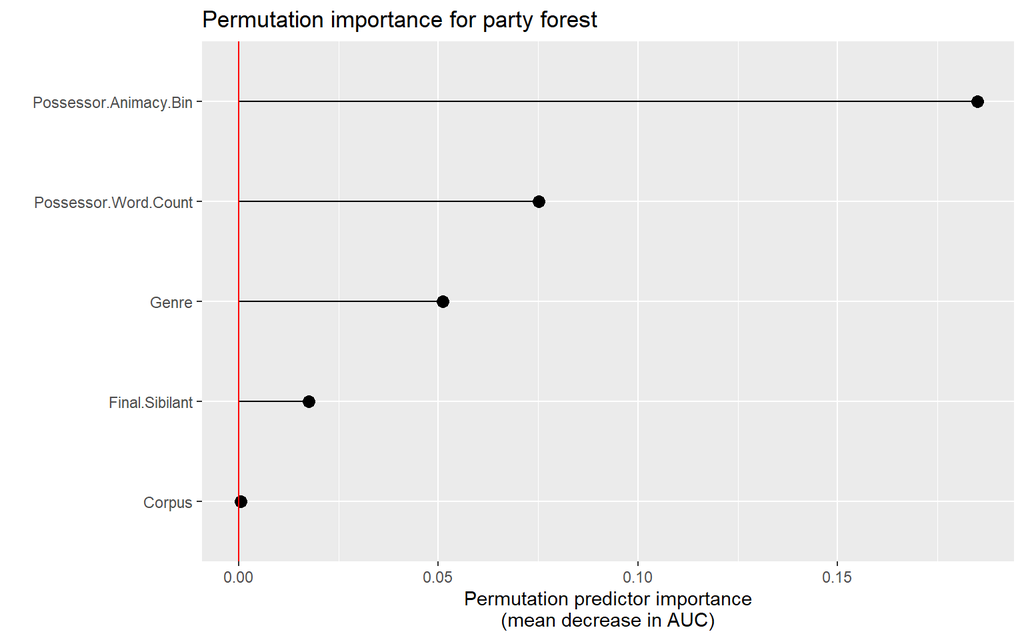

```r
gen_party1_varimp_df <- gen_party1_varimp$values %>%
  as.data.frame %>%
  rename(varimp = ".") %>%
  mutate(pred = rownames(.) %>% factor)

p1 <- gen_party1_varimp_df %>%
  ggplot(aes(fct_reorder(pred, varimp), varimp)) +
  geom_segment(aes(xend = pred, yend = 0)) +
  geom_point(size = 3) +
  labs(x = "", y = "Permutation predictor importance\n(mean decrease in AUC)") +
  geom_hline(yintercept = 0, color = "red") +
  coord_flip() +
  ggtitle("Permutation importance for party forest")
p1
```

By chance, the random reordering of values sometimes results in a configuration that affords a slightly *better* model. This may arise when the values of an irrelevant predictor are reshuffled. In other words, the random reshuffling created a new version of the predictor that is actually *more* strongly associated with the outcome than the original predictor. This has the effect of creating a negative variable importance score.

It’s important to remember that these variable importance scores should only be interpreted relative to each other as a ranking of the model’s predictors. The absolute values of the scores should not be interpreted or compared across studies (see Strobl et al. 2009:336).

Since the forest are random, they should also be verified by fitting multiple models with different random seeds and ntree numbers.

Conditional importances also take a bit longer to run.

```r
# track the time it takes to run
tic()
gen_party1_varimp_cond <- permimp(
  gen_party1,
  AUC = TRUE, # use the AUC (concordance index) rather than accuracy
  progressBar = FALSE, # don't print a progress bar here,
  conditional = TRUE
  )
toc()
```

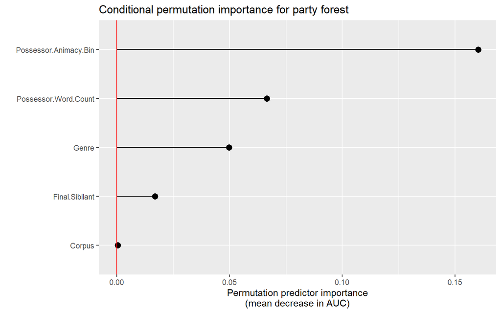

```r
gen_party1_varimp_cond_df <- gen_party1_varimp_cond$values %>%
  as.data.frame %>%
  rename(varimp = ".") %>%
  mutate(pred = rownames(.) %>% factor)

p2 <- gen_party1_varimp_cond_df %>%
  ggplot(aes(fct_reorder(pred, varimp), varimp)) +
  geom_segment(aes(xend = pred, yend = 0)) +
  geom_point(size = 3) +
  labs(x = "", y = "Permutation predictor importance\n(mean decrease in AUC)") +
  geom_hline(yintercept = 0, color = "red") +
  coord_flip() +
  ggtitle("Conditional permutation importance for party forest")
p2
```

As you can see, this doesn’t always make much difference, but it can.

# Partial dependencies

As I mentioned above, reading effects of individual predictors off a random forest model is not easy because a forest—as the name implies—can contain many hundreds or even thousands of potentially very different trees. There is therefore no method for computing *p*-values for individual predictors effects or their interactions.

That said, we can examine the effects of an individual predictor (and its relation to other predictors), we plot the **partial dependence** of the probability of the response on that predictor or predictors, while averaging over the values of the other predictors. This method is similar in spirit to partial effects plots derived from regression models, though these should not be interpreted as significance tests.

There is a nice package `edarf` that can quickly calculate partial dependence plots with a convernient `partial_dependence()` function.

```r
library(edarf)
```

> There is a more recent package `{pdp}` which can be used for calculating partial dependencies, but it is *very* time consuming, even for `ranger` models. For `party` models I’ve had processes run for +10 hours before cancelling.

### Categorical responses

Let’s estimate the partial dependency of genitive constructions on Genre in the `randomForest` model.

```r
set.seed(1234)
pd_ranFor1 <- partial_dependence(
  gen_for_randomForest,
  vars = 'Genre',
  n = c(5, 100),
  data = gens)
pd_ranFor1
```

| Genre | of | s |
| --- | --- | --- |
| General Fiction | 0.659330 | 0.340670 |
| Learned | 0.671655 | 0.328345 |
| Non-fiction | 0.660410 | 0.339590 |
| Press | 0.499575 | 0.500425 |
| Western Fiction | 0.663955 | 0.336045 |

The package has its own plot function `plot_pd()`, but I’ve found it to be a bit buggy, and so I perfer to do things my own way.

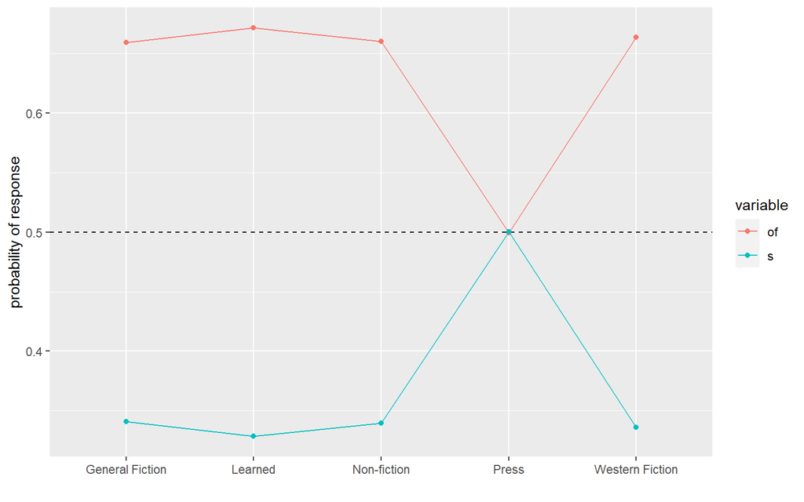

```r
pd_ranFor1 %>%
  as.data.frame %>%
  reshape2::melt(id.vars = "Genre") %>%
  ggplot(aes(x = Genre,
             y = value,
             color = variable,
             group = variable)) +
  geom_hline(yintercept = .5, linetype = 2) +
  geom_line() +
  geom_point() +
  labs(x = "", y = "probability of response")
```

We can plot interactions easily too. Let’s look at how the effect of Possessor animacy changes across genres.

```r
set.seed(1234)
pd_ranFor2 <- partial_dependence(gen_for_randomForest,
  vars = c('Genre', 'Possessor.Animacy.Bin'),
  n = c(10, 100), # we set the first number to 2 animacy levels x 5 genres = 10
  data = gens,
  interaction = TRUE)
pd_ranFor2
```

| Genre | Possessor.Animacy.Bin | of | s |
| --- | --- | --- | --- |
| General Fiction | Anim | 0.403175 | 0.596825 |
| General Fiction | Inanim | 0.832235 | 0.167765 |
| Learned | Anim | 0.412110 | 0.587890 |
| Learned | Inanim | 0.852180 | 0.147820 |
| Non-fiction | Anim | 0.424875 | 0.575125 |
| Non-fiction | Inanim | 0.830400 | 0.169600 |
| Press | Anim | 0.333805 | 0.666195 |
| Press | Inanim | 0.576965 | 0.423035 |
| Western Fiction | Anim | 0.435550 | 0.564450 |
| Western Fiction | Inanim | 0.822200 | 0.177800 |

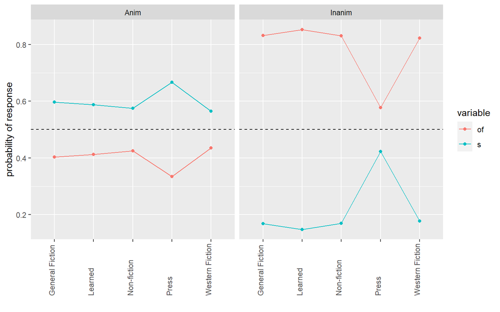

```r
pd_ranFor2 %>%
  as.data.frame %>%
  reshape2::melt(id.vars = c("Genre", "Possessor.Animacy.Bin")) %>%
  ggplot(aes(x = Genre,
             y = value,
             color = variable,
             group = variable)) +
  geom_hline(yintercept = .5, linetype = 2) +
  geom_line() +
  geom_point() +
  facet_wrap(~ Possessor.Animacy.Bin, ncol = 2) +
  labs(x = "", y = "probability of response") +
  theme(axis.text.x = element_text(angle = 90, hjust = 0, vjust = 0))
```

Maybe not the best plot, but we get the picture that the animacy effect is substantially weakened in Press texts compared to the other genres.

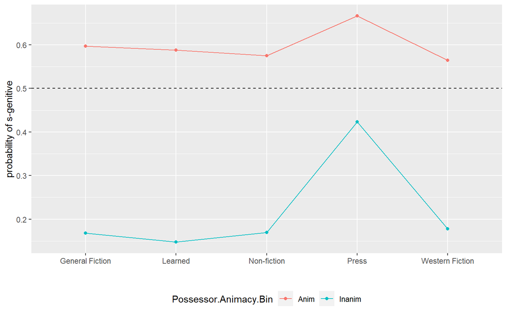

```r
# another way of looking at it where we only plot the probability of one response
pd_ranFor2 %>%
  as.data.frame %>%
  ggplot(aes(x = Genre, y = s,
             color = Possessor.Animacy.Bin,
             group = Possessor.Animacy.Bin)) +
  geom_hline(yintercept = .5, linetype = 2) +
  geom_line() +
  geom_point() +
  labs(x = "", y = "probability of s-genitive") +
  theme(legend.position = "bottom")
```

Plotting effects of continuous predictors is a bit trickier, but it’s all a matter of setting the desired values. For example, let’s look at the influence of relative clause length on the choice of relativizer.

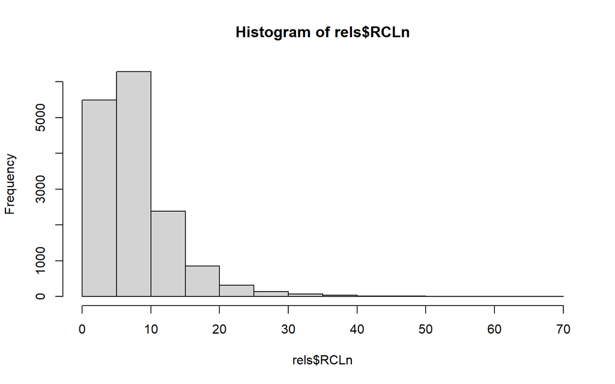

```r
hist(rels$RCLn)
```

```r
quantile(rels$RCLn, .9)
```

```
90%
 15
```

We’ll increase the number of levels and samples to compute the probabilities over. From the plot we can see that the longer the RC gets, the more likely an overt relativizer becomes.

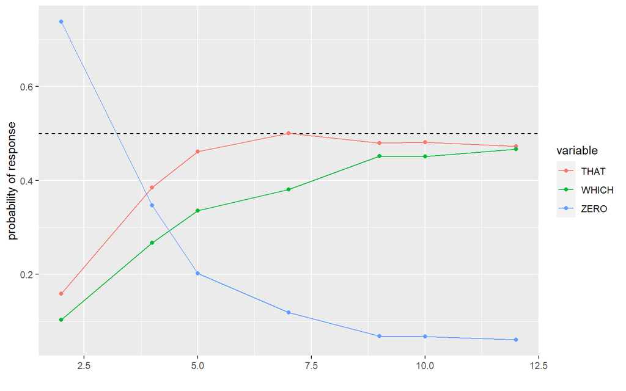

```r
set.seed(1234)
partial_dependence(rel_randomForest,
  vars = "RCLn",
  n = c(40, 100),
  data = rels,
  interaction = FALSE) %>%
  as.data.frame() %>%
  subset(RCLn <= 12) %>%
  reshape2::melt(id.vars = "RCLn") %>%
  ggplot(aes(x = RCLn,
             y = value, # include only the
             color = variable,
             group = variable)) +
  geom_hline(yintercept = .5, linetype = 2) +
  geom_line() +
  geom_point()+
  labs(x = "", y = "probability of response")
```

We can do the same with all the “main effects” simultaneously with a little knowledge of loops. First we create a vector of all the predictors in our formula (we’ll just focus on a subset here)

```r
f <- rel ~ time2 + RCLn + variety + antLN
# leave out the response
vars <- all.vars(f)[-1]
```

```r
pd.func <- function(x) {
  nlevs <- ifelse(is.factor(rels[, x]), nlevels(rels[, x]), 20)
  set.seed(1234)
  p <- partial_dependence(rel_randomForest,
    vars = x, n = c(nlevs, 100), data = rels) %>%
    reshape2::melt(id.vars = x) %>%
    ggplot(aes_string(x = x, y = 'value', group = 'variable')) +
    geom_hline(yintercept = .5, linetype = 'dashed') +
    geom_line(aes(color = variable)) +
    geom_point(aes(color = variable)) +
    labs(x = x, y = 'predicted probability')
  return(p)
}
```

```r
# loop through predictors and get the partial dependency plots
partials <- vector("list")
for (i in 1:length(vars)){
  partials[[i]] <- pd.func(vars[i])
}
names(partials) <- vars
```

Finally, we’ll arrange these all in a single plot grid.

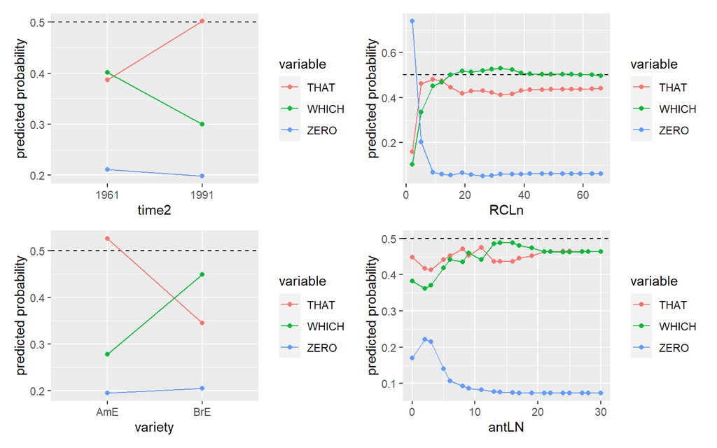

```r
wrap_plots(partials, ncol = 2)
```

Alternatively, you could plot each predictor individually with `partials[[i]]` where `i` is either the name of the predictor or the number of its place in the list.

## Continuous responses

Continuous responses can be included just as easily.

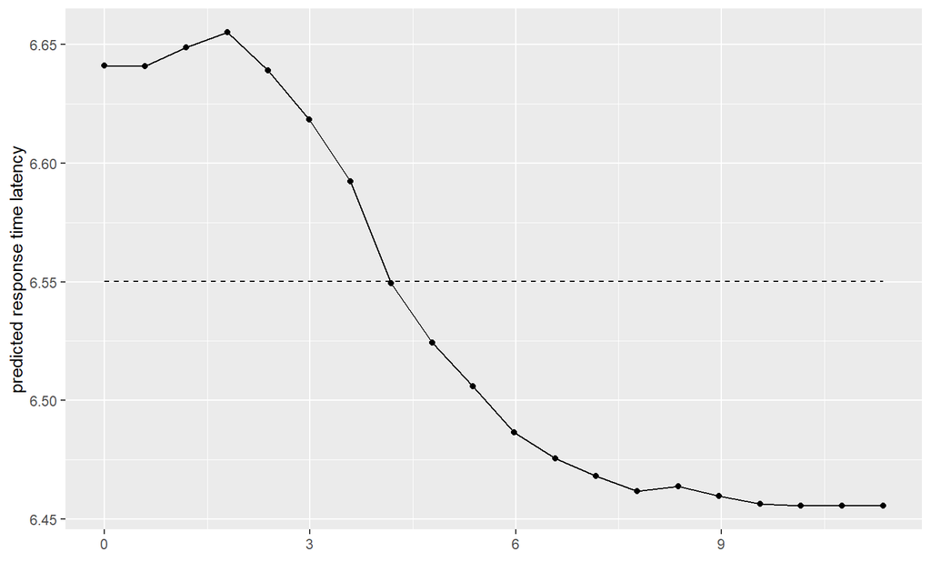

```r
set.seed(1234)
partial_dependence(lexdec_randomForest,
  vars = "WrittenFrequency",
  n = c(20, 50),
  data = english,
  interaction = FALSE) %>%
  as.data.frame() %>%
  ggplot(aes(x = WrittenFrequency,
             y = RTlexdec)) +
  geom_line() +
  geom_point() +
  annotate(geom = "segment", # we'll add a line for the mean
           x = min(english$WrittenFrequency),
           xend = max(english$WrittenFrequency),
           y = mean(english$RTlexdec),
           yend = mean(english$RTlexdec), linetype = 2) +
  labs(x = "", y = "predicted response time latency")
```

# Summary

Advantages of random forests:

- **Small n, big p**: Random forests can handle small datasets with relatively large sets of predictors. This is a problem for other methods
- Random forests are also robust against problems of collinearity due to their bagging and random variable selection procedures.
- Random forests deal well with nonlinear effects and high-order interactions (though care should be taken, see Wright et al. 2016)
- **Very accurate**: Random forests are typically much more accurate than single trees and even regression models

Disadvantages of random forests:

- Cannot handle non-independence well. They don’t have a way of incorporating hierarchical data structures, i.e.“random” effects for speaker, text, etc.
- Potentially long computing time (especially for variable imortance)
- Do not provide traditional measures of effect size, direction, or significance